# Question 1

## Pre-requisites

- An Signed Distance Function (SDF) is a mathematical function that gives the shortest distance from any point in space to the surface of a shape, with a sign indicating whether the point is inside or outside the shape.
- A Signed Distance Function (SDF) represents a surface implicitly and provides numerous benefits. It’s particularly useful for boolean operations, collision detection, ray marching, modeling, and physics simulations.

```python
## Run this shell for setting up env
!pip install trimesh pyglet networkx shapely rtree
import numpy as np
import trimesh
import plotly.graph_objects as go
from skimage import measure


# Utility funcs for visualization
def get_pcl_trace(surface_points,size,color,opacity=1):
    points_trace = go.Scatter3d(
        x=surface_points[:, 0],
        y=surface_points[:, 1],
        z=surface_points[:, 2],
        mode='markers',
        marker=dict(
            size=size,
            color=color,
            opacity=0.8
        )
    )
    return points_trace

def get_mesh_trace(mesh,color,opacity=1):
    vertices = mesh.vertices
    faces = mesh.faces

    mesh_trace = go.Mesh3d(
        x=vertices[:, 0],
        y=vertices[:, 1],
        z=vertices[:, 2],
        i=faces[:, 0],
        j=faces[:, 1],
        k=faces[:, 2],
        color=color,
        opacity=opacity,
    )
    return mesh_trace

def get_cone_trace(surface_points,surface_normals,size=1):
    sn = surface_normals / np.linalg.norm(surface_normals, axis=1, keepdims=True)
    cone_trace = go.Cone(
        x=surface_points[:, 0],
        y=surface_points[:, 1],
        z=surface_points[:, 2],
        u=sn[:, 0],
        v=sn[:, 1],
        w=sn[:, 2],
        sizemode="absolute",
        sizeref=size,
        anchor='tail',
        colorscale=[[0, 'blue'], [1, 'blue']],
        showscale=False,
    )
    return cone_trace

def view_trace(data):
    fig = go.Figure(data=data)
    fig.update_layout(
        scene=dict(
            xaxis_title='X',
            yaxis_title='Y',
            zaxis_title='Z'
        ),
        margin=dict(r=0, l=0, b=0, t=0)
    )

    fig.show()
```

## Q 1.a

Define the implicit Signed Distance Function (SDF) for a sphere centered at the origin with a radius of 0.5. The function should accept a point as input and return its signed distance to the sphere’s surface — positive if the point is outside, negative if it’s inside.

```python
import numpy as np
def sphere_sdf(point):
    center =  np.array([0, 0, 0])
    radius = 0.5
    ##
    # Write your code here
    x = np.linalg.norm(point-center)
    if x > radius:
        sdf_at_point = -1 * (radius - x)
    else:
        sdf_at_point = (x - radius)
    ## Could have had directly written
    # sdf_at_point = np.linalg.norm(point-center) - radius
    # Just for explanation and readability wrote in expanded form
    ## Remove the following
    return sdf_at_point
```

### Visualization

Let’s create a 64x64x64 voxel grid for a unit cube centered at the origin, with a side length of 2, ranging from -1 to 1 and evaluate sdf at all voxels.

We can determine if a voxel lies on the surface by checking if its SDF value is close to zero (within a given threshold). The provided code can help visualize all voxels-- in red, and the points on (near) the surface-- in blue.

Learn about marching cubes algorithm-- it allows us to extract the surface implicitly represented by SDF.

```python
grid_size = 64
x = np.linspace(-1, 1, grid_size)
y = np.linspace(-1, 1, grid_size)
z = np.linspace(-1, 1, grid_size)

X, Y, Z = np.meshgrid(x, y, z, indexing='ij')
points = np.stack((X, Y, Z), axis=-1)
sdf_values = np.apply_along_axis(sphere_sdf, -1, points)
```

```python
# Visualize Grid (Red) and Points near sphere surface (Blue).

pt = get_pcl_trace(points.reshape(-1, 3),size=1,color='red',opacity=0.3)

surface_threshold = 0.02
surface_points = points[np.abs(sdf_values) < surface_threshold]
spt = get_pcl_trace(surface_points.reshape(-1, 3),size=5,color='blue',opacity=1)

data = [pt,spt]
view_trace(data)
```

[output not shown]

```python
# Visualize Mesh
verts, faces, _, _ = measure.marching_cubes(sdf_values, level=0, spacing=(2/grid_size, 2/grid_size, 2/grid_size))
verts = verts - 1
mesh = trimesh.Trimesh(vertices=verts, faces=faces)
mt = get_mesh_trace(mesh,color='red',opacity=0.8)
vts = get_pcl_trace(mesh.vertices,size=2,color='yellow',opacity=1)
data = [mt,vts]
view_trace(data)
```

[output not shown]

## Q 1.b

Calculate the normals for the surface represented by SDF. A normal is a vector that is perpendicular to the surface at a given point, typically pointing outward from the object’s surface.

### Hint: Consider calculating the spatial gradient of the SDF using finite differences for voxel grid and filter normals belonging to `surface_points`

Why does computing the spatial gradient of an SDF using finite differences at surface points yield the surface normals? Describe elaboratively and provide code in following cell.

```python
###
# Add explanation here as comment
# Gradient -----> direction of steepest increase

# Gradient of a scalar and Divergence of a vector (mathematically)

# For any surface defined by f(x, y, z) = c (with c being a constant),
# the gradient vector ∇f = [∇f/∇x, ∇f/∇y, ∇f/∇z]
# This same gradient is also orthogonal to the surfaces where f remains constant.

# To illustrate, take any curve r(t) that lies on the surface. r : R -----> R^3
# Because the curve is entirely on the surface, f(r(t)) stays constant at c for all t.

# Differentiating f(r(t)) with respect to t gives:
#   d/dt [f(r(t))] = 0

# By the chain rule:
#   d/dt [f(r(t))] = ∇f(r(t)) ⋅ dr/dt

# Since the derivative is zero, we get:
#   ∇f ⋅ dr/dt = 0

# This result shows that the gradient ∇f is perpendicular to the tangent vector dr/dt of the curve.(because dot prod =0)
# Since this applies to every possible curve on the surface,
# it follows that ∇f is perpendicular to the entire tangent plane at that point.


###


def sdf_gradient(sdf_values, surface_points=None):
    ##
    # Write your code here, change input args as required
    # Computing gradients of the signed distance field (SDF) using central differences.
    # Gradient approximation:
    # ∇f(x, y, z) ≈ [(f(x + h, y, z) - f(x - h, y, z)) / 2h,
    #                (f(x, y + h, z) - f(x, y - h, z)) / 2h,
    #                (f(x, y, z + h) - f(x, y, z - h)) / 2h]

    # grad_x, grad_y, grad_z store the partial derivatives of the SDF along x, y, and z directions.
    grad_x= np.zeros_like(sdf_values)
    grad_y= np.zeros_like(sdf_values)
    grad_z= np.zeros_like(sdf_values)

    spacing = 2/64

    grad_x[1:-1, :, :] = (sdf_values[2:, :, :] - sdf_values[:-2, :, :]) / (2 * spacing)
    grad_y[:, 1:-1, :] = (sdf_values[:, 2:, :] - sdf_values[:, :-2, :]) / (2 * spacing)
    grad_z[:, :, 1:-1] = (sdf_values[:, :, 2:] - sdf_values[:, :, :-2]) / (2 * spacing)

    grad_x[0,:,:] = (sdf_values[1,:,:] - sdf_values[-1,:,:]) / (2 * spacing)
    grad_x[-1, :, :] = (sdf_values[0, :, :] - sdf_values[-2, :, :]) / (2 * spacing)

    grad_y[:,0,:] = (sdf_values[:,1,:] - sdf_values[:,-1,:]) / (2 * spacing)
    grad_y[:, -1, :] = (sdf_values[:, 0, :] - sdf_values[:, -2, :]) / (2 * spacing)

    grad_z[:,:,0] = (sdf_values[:,:,1] - sdf_values[:,:,-1]) / (2 * spacing)
    grad_z[:, :, -1] = (sdf_values[:, :, 0] - sdf_values[:, :, -2]) / (2 * spacing)


            # Create a grid of indices
    indices = np.round(((surface_points + 1) * (grid_size - 1) / 2)).astype(int)
    # Extract gradients at surface points
    normals = np.zeros_like(surface_points)
    for i in range(len(surface_points)):
        x, y, z = indices[i]
        # Combine gradient components into a vector
        normal = np.array([grad_x[x, y, z], grad_y[x, y, z], grad_z[x, y, z]])
        # Normalize to get unit vector
        normals[i] = normal / (np.linalg.norm(normal) + 1e-10)  # Add small epsilon to avoid division by zero

    return normals


surface_normals = sdf_gradient(sdf_values,surface_points=surface_points)
ct = get_cone_trace(surface_points,surface_normals,size=1) # Try changing size here, if cones too large or invisible!
data = [ct]
view_trace(data)
```

[interactive chart not shown]

### Visualizing Normals

```python
## Illustration for plotting normals of extracted mesh by marching cubes
vertex_normals = mesh.vertex_normals
vertices = mesh.vertices
ct = get_cone_trace(vertices,vertex_normals,size=1)  # Try changing size here, if cones too large or invisible!
data = [ct,mt]
view_trace(data)
```

[interactive chart not shown]

# Question 2

How can Singular Value Decomposition (SVD) be used to compress and reconstruct images efficiently, and what role do singular values play in preserving image features?

- Reconstruct the image using only the top k singular values.
- Experiment with different values of k and visualize the results.
- Plot reconstruction error by measuring Mean squared error between reconstructed and original image for different values of k.
- Write a brief note on how this can be beneficial for image compression applications.

### Singular Value Decomposition (SVD) for Image Compression

Singular Value Decomposition (SVD) is used for image compression by decomposing an image into **U**, **S**, and **V** matrices. The **S** matrix contains singular values in descending order, representing the importance of image features. By retaining only the top **k** singular values, you can compress the image while preserving its essential features.

#### Key Points:

- **Decomposition**: $$ A = U \Sigma V^T $$
- **Compression**: Retain top **k** singular values in Σ
- **Role of Singular Values**: Preserve important features by filtering out less significant ones.

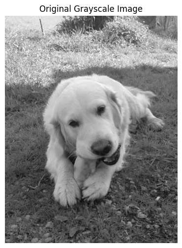

```python
import numpy as np
import matplotlib.pyplot as plt
import imageio.v2 as imageio
from skimage.color import rgb2gray

url = "https://upload.wikimedia.org/wikipedia/commons/a/af/Golden_retriever_eating_pigs_foot.jpg"  # If this image becomes unavailable (rare!) read some other from web
image = imageio.imread(url)

gray_image = rgb2gray(image)

plt.figure(figsize=(6, 6))
plt.imshow(gray_image, cmap='gray')
plt.title('Original Grayscale Image')
plt.axis('off')
plt.show()
```

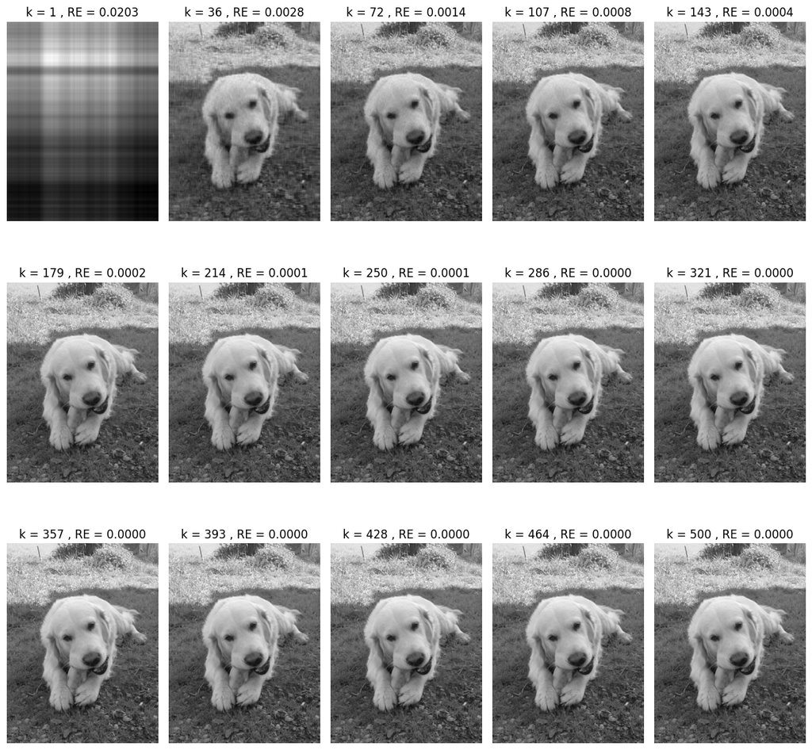

```python
def compress_image_using_topk_singular_values(image, k):
    ## Your code here
    U, Sigma, Vt = np.linalg.svd(image)
    U_k = U[:, :k]
    Sigma_k = np.diag(Sigma[:k])
    Vt_k = Vt[:k, :]
    image = U_k@Sigma_k@ Vt_k

    compressed_image= image
    return compressed_image

def reconstruction_error(original, reconstructed):
    mse = np.mean((original - reconstructed) ** 2)
    return mse
    ## Your code here

m, n = gray_image.shape
k_values = np.linspace(1, min(m, n), 15, dtype=int)  # Lets visualize 15 images
plt.figure(figsize=(12, 12))
for i, k in enumerate(k_values):
    compressed_image = compress_image_using_topk_singular_values(gray_image, k)
    re = reconstruction_error(gray_image, compressed_image)
    plt.subplot(3, 5, i + 1)
    plt.imshow(compressed_image, cmap='gray')
    plt.title(f'k = {k} , RE = {re:.4f}')
    plt.axis('off')

plt.tight_layout()
plt.show()
```

$$ MSE = \frac{1}{mn} \sum_{i=1}^{m} \sum_{j=1}^{n} \left( A_{i,j} - (A_k)_{i,j} \right)^2 $$

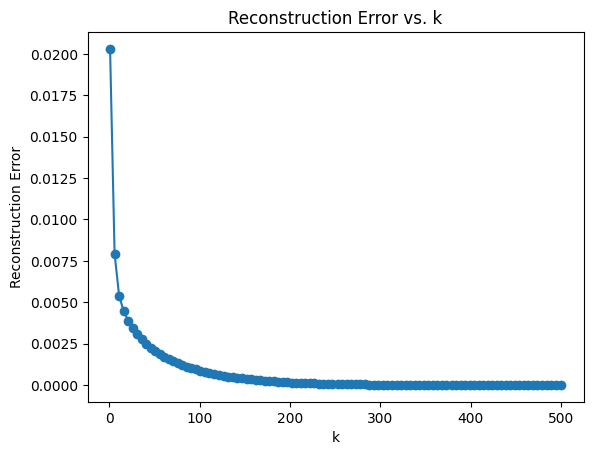

```python
# Plot Reconstruction error w.r.t. 'k'
k_values = np.linspace(1, min(m, n), 100, dtype=int)  # Lets sample more 100 k values for analysing how k affects reconstruction quality.
## Your code here for plot

def reconstruction_error(original, reconstructed):
    mse = np.mean((original - reconstructed) ** 2)
    return mse

reconstruction_errors = []
for k in k_values:
    compressed_image = compress_image_using_topk_singular_values(gray_image, k)
    re = reconstruction_error(gray_image, compressed_image)
    reconstruction_errors.append(re)

plt.plot(k_values, reconstruction_errors, marker='o')
plt.xlabel('k')
plt.ylabel('Reconstruction Error')
plt.title('Reconstruction Error vs. k')
```

#### Write a brief note on

- (a) how this can be beneficial for image compression applications
- (b) how k affects reconstruction quality.

## Advantages for Image Compression

Utilizing Singular Value Decomposition (SVD) for image compression offers several benefits:

- **Efficient Storage**: By retaining only a subset of singular values and their corresponding vectors, significant storage savings are achieved without compromising essential image features.
- **Progressive Transmission**: Transmitting singular values in descending order of significance allows for an initial quick display of a recognizable image, with finer details progressively refined.
- **Noise Reduction**: Eliminating smaller singular values, which often represent noise, enhances overall image clarity.

## Influence of ( k ) on Reconstruction Quality

The parameter ( k ), representing the number of singular values retained, directly impacts the quality of the reconstructed image:

- **Low ( k ) Values**: Capturing the most critical image features with minimal storage, resulting in rapid quality improvements.
- **High ( k ) Values**: As ( k ) increases, each additional singular value contributes less to visual quality, leading to diminishing returns in reconstruction improvement.
- **Optimal ( k ) Selection**: Balancing ( k ) is crucial to achieve desired compression efficiency while maintaining acceptable image fidelity.